# Analysing Indian Media On Youtube.

- Idea is to pull the title and description of youtube videos for various Indian Media Outlets and perform text analytics on it
- Goal of doing the text analytics is to try and analyze the topics frequently discussed and figure out if outlets can be categorized.
- Not for me to draw conclusions, therefore I will just leave the data and charts *as is*

### Install Spacy

Spacy provides trained word to vector models that can be used for part of speech tagging / entity extraction etc. We will use it later in the analysis

```python
!pip install spacy
```

```python
import spacy.cli
spacy.cli.download("en_core_web_md")
```

```
✔ Download and installation successful
You can now load the model via spacy.load('en_core_web_md')
```

## Text Preprocessing

NLTK provides various text analysis features including basic functionality like removing stopwords, tokenizing words etc.

Let's import the module below

```python
import nltk
from nltk.corpus import stopwords
```

```python
nltk.download('stopwords')
nltk.download('punkt')
```

```
True
```

Adding "episode" to the set of stopwords because it appears quite a few times in the description of the youtube videos

```python
stopwords_set = stopwords.words('english')
stopwords_set = set(stopwords_set).union(set(["episode"]))
```

### Import numpy and Pandas

```python
import numpy as np
import pandas as pd
```

- Read the data in

```python
df = pd.read_csv("text.csv")
```

```python
df.head()
```

|  | Channel Id | Playlist Title | Date | Title | Description |
| --- | --- | --- | --- | --- | --- |
| 0 | WIRE | Daily COVID-19 Updates | 2020-03-23T16:03:58Z | Coronavirus Updates, March 23: States Shut Bor... | As of Monday morning, there were 415 total con... |
| 1 | WIRE | Daily COVID-19 Updates | 2020-03-24T17:32:43Z | Coronavirus Updates, March 24: Nation on Lockd... | Since yesterday, 99 new cases of COVID 19 have... |
| 2 | WIRE | Daily COVID-19 Updates | 2020-03-25T16:50:07Z | Coronavirus Updates, March 25: Chaos in Supply... | As of Wednesday evening, there were 553 confi... |
| 3 | WIRE | Daily COVID-19 Updates | 2020-03-26T16:34:57Z | Coronavirus Updates, March 26: Economic Relief... | As of Thursday morning, there were 593 active ... |
| 4 | WIRE | Daily COVID-19 Updates | 2020-03-27T16:37:35Z | Coronavirus Updates, March 27: Unprotected Med... | As of Friday morning, 724 people with COVID-19... |

### Data

- Each row in the data represents one video
- data has 5 columns
1. **Channel Id** - Provides the Indian Media Channel Id that can be used to uniquely identify the outlet
2. **Playlist title** is the title of the playlist to which the video
3. **Date** - Date when the episode was published
4. **Title** - Title of the video
5. **Description** - Description of the video

### Lets see how many unique media outlets we have

```python
df["Channel Id"].unique()
```

```
array(['WIRE', 'PRINT', 'INDIA_TODAY', 'REPUBLIC_WORLD'], dtype=object)
```

- Lets drop duplicate video information (if any)

```python
df = df.drop_duplicates()
```

Lets check how many video information we have

```python
df.shape
```

```
(14246, 5)
```

Lets drop video informations that have NA in them

```python
df = df.dropna()
```

Let's combine the Title and description of each video to another field called 'text'. This will allow easier analysis.

```python
df["text"] = df["Title"] + "\n" + df["Description"]
```

```python
df["text"].head()
```

```
0    Coronavirus Updates, March 23: States Shut Bor...
1    Coronavirus Updates, March 24: Nation on Lockd...
2    Coronavirus Updates, March 25: Chaos in Supply...
3    Coronavirus Updates, March 26: Economic Relief...
4    Coronavirus Updates, March 27: Unprotected Med...
Name: text, dtype: object
```

```python
# Lower the text
df["text"] = df["text"].str.lower()
```

### Text Processing

- To tokenize the sentences we can use the Regexp Tokenizer provided by NLTK

```python
from nltk import RegexpTokenizer
```

Below variable 'promotion' includes text that is identified as advertisement or promotional, so that the tokens included in that variable can be excluded from further analysis. This will lead to loss of some information but more importantly will remove garbage from the text.

```python
promotion = """
like our work?  click here to support the wire: https://thewire.in/support

the founding premise of the wire is this: if good journalism is to survive and thrive, it can only do so by being both editorially and financially independent. this means relying principally on contributions from readers and concerned citizens who have no interest other than to sustain a space for quality journalism. as a publication, the wire will be firmly committed to the public interest and democratic values.
we publish in four different languages!
for english, visit www.thewire.in
for hindi: http://thewirehindi.com/
for urdu: http://thewireurdu.com
for marathi: https://marathi.thewire.in
if you are a young writer or a creator, you can submit articles, essays, photos, poetry – anything that’s straight out of your imagination – to livewire, the wire’s portal for the young, by the young. https://livewire.thewire.in/
you can also follow the wire’s social media platforms and engage with us.
facebook
https://www.facebook.com/thewire/
https://www.facebook.com/thewirehindi/
https://www.facebook.com/thewireurdu/
https://www.facebook.com/thewiremarathi/
twitter
https://twitter.com/thewire_in
https://twitter.com/thewirehindi
https://twitter.com/thewireurdu
https://twitter.com/thewiremarathi
https://twitter.com/livewire
instagram
https://www.instagram.com/thewirein/
https://www.instagram.com/livewirein/
don’t forget to hit the subscribe button to never miss a video from the wire!
"""
```

```python
tokenizer = nltk.RegexpTokenizer(r"\w{3,}")
```

```python
promotion = set(tokenizer.tokenize(promotion))
```

After the above line now 'promotion' variable holds all tokens that we want to ignore.

### Document Vectors

- Now to continue with our processing of data we Import CountVectorizer and TfidfVectorizer.
- TfidfVectorizer converts a collection of raw documents to a matrix of TF-IDF features.
  - This will allow us to form a basic vocobulary across media outlets
  - We don't want words/terms that are mostly/only used by one outlet to show up in our analysis because our analysis is mostly going to be comparitive. If words don't appear across channels then there won't be much to compare.
  - We can also use CountVectorizer to meet our above goal, as the only thing needed is the vocabulary.

```python
from sklearn.feature_extraction.text import CountVectorizer , TfidfVectorizer
```

Let's create a function getVocab

This function takes as input a dataframe and then fits a CountVectorizer to the "text" column of the dataframe and returns the learned vocabulary as a set

```python
def getVocab(df):
  vectorizer = CountVectorizer(min_df=5)
  vectorizer.fit(df["text"])
  return set(vectorizer.get_feature_names())
```

Now to get Vocabulary of each of the outlet we first group by the *channel id* and then apply our function *getVocab*

```python
vocabs = df.groupby("Channel Id").apply(getVocab)
```

```python
final_vocab = CountVectorizer(min_df=2).fit([" ".join(list(v)) for v in vocabs]).get_feature_names()
```

```python
len(final_vocab)
```

```
2585
```

Now let's move on to tokenizing *text* of each video. The idea is to

- Remove the stop words
- Remove words in promotion
- Keep Only words that are in final_vocab

```python
def tokenizeRows(sent):
  try:
    #print(sent)
    tokens = [w for w in tokenizer.tokenize(sent) if w not in stopwords_set and w not in promotion and w in final_vocab]
    return " ".join(tokens)
  except:
    return None
```

```python
df["filtered_text"] = df["text"].apply(tokenizeRows)
df = df.dropna()
```

```python
df.head()
```

|  | Channel Id | Playlist Title | Date | Title | Description | text | filtered_text |
| --- | --- | --- | --- | --- | --- | --- | --- |
| 0 | WIRE | Daily COVID-19 Updates | 2020-03-23T16:03:58Z | Coronavirus Updates, March 23: States Shut Bor... | As of Monday morning, there were 415 total con... | coronavirus updates, march 23: states shut bor... | coronavirus updates march states shut tests po... |
| 1 | WIRE | Daily COVID-19 Updates | 2020-03-24T17:32:43Z | Coronavirus Updates, March 24: Nation on Lockd... | Since yesterday, 99 new cases of COVID 19 have... | coronavirus updates, march 24: nation on lockd... | coronavirus updates march nation lockdown days... |
| 2 | WIRE | Daily COVID-19 Updates | 2020-03-25T16:50:07Z | Coronavirus Updates, March 25: Chaos in Supply... | As of Wednesday evening, there were 553 confi... | coronavirus updates, march 25: chaos in supply... | coronavirus updates march chaos supply first d... |
| 3 | WIRE | Daily COVID-19 Updates | 2020-03-26T16:34:57Z | Coronavirus Updates, March 26: Economic Relief... | As of Thursday morning, there were 593 active ... | coronavirus updates, march 26: economic relief... | coronavirus updates march economic relief pack... |
| 4 | WIRE | Daily COVID-19 Updates | 2020-03-27T16:37:35Z | Coronavirus Updates, March 27: Unprotected Med... | As of Friday morning, 724 people with COVID-19... | coronavirus updates, march 27: unprotected med... | coronavirus updates march treat covid patients... |

As is seen above, the *filtered_text* column now containes trimmed down sentences which include only tokens of interest.

### Document Vectors

- Now finally we can convert each video text to a vector using the Tfidf Vectorizer.
- Few parameters that we use here are
  - *ngram_range* - this parameter can be used to create ngrams as well apart from just including single words.
  - *min_df* - we want the tokens to appear in atleast 10 videos for them to be considered part of the vocabulary
  - *max_df* - We want to remove tokens that appear in more than fraction of all videos

```python
cvect = TfidfVectorizer(ngram_range=(1,1) , min_df=10 ,max_df=0.5)
allSentsCounts = cvect.fit_transform(df["filtered_text"])
```

```python
allSentsCounts.shape
```

```
(14241, 2236)
```

```python
allSentsCounts[:2]
```

```
<2x2236 sparse matrix of type '<class 'numpy.float64'>'
	with 94 stored elements in Compressed Sparse Row format>
```

```python
countdf = pd.DataFrame(allSentsCounts.toarray()  , columns=cvect.get_feature_names() , index=df.index)
countdf.head()
```

|  | 000 | 100 | 144 | 1971 | 1984 | 200 | 2012 | 2015 | 2016 | 2018 | 2019 | 2020 | 20th | 2nd | 370 | 3rd | 439 | 500 | 600 | 71st | aadhaar | aaditya | aadmi | aam | aap | abdullah | abhishek | able | abrogation | … |
| --- | --- | --- | --- | --- | --- | --- | --- | --- | --- | --- | --- | --- | --- | --- | --- | --- | --- | --- | --- | --- | --- | --- | --- | --- | --- | --- | --- | --- | --- | --- |
| 0 | 0.000000 | 0.00000 | 0.129564 | 0.0 | 0.0 | 0.115974 | 0.0 | 0.0 | 0.0 | 0.0 | 0.0 | 0.0 | 0.0 | 0.0 | 0.0 | 0.0 | 0.0 | 0.000000 | 0.0 | 0.0 | 0.0 | 0.0 | 0.0 | 0.0 | 0.0 | 0.0 | 0.0 | 0.0 | 0.0 | … |
| 1 | 0.000000 | 0.11606 | 0.000000 | 0.0 | 0.0 | 0.000000 | 0.0 | 0.0 | 0.0 | 0.0 | 0.0 | 0.0 | 0.0 | 0.0 | 0.0 | 0.0 | 0.0 | 0.127254 | 0.0 | 0.0 | 0.0 | 0.0 | 0.0 | 0.0 | 0.0 | 0.0 | 0.0 | 0.0 | 0.0 | … |
| 2 | 0.000000 | 0.00000 | 0.000000 | 0.0 | 0.0 | 0.000000 | 0.0 | 0.0 | 0.0 | 0.0 | 0.0 | 0.0 | 0.0 | 0.0 | 0.0 | 0.0 | 0.0 | 0.000000 | 0.0 | 0.0 | 0.0 | 0.0 | 0.0 | 0.0 | 0.0 | 0.0 | 0.0 | 0.0 | 0.0 | … |
| 3 | 0.000000 | 0.00000 | 0.000000 | 0.0 | 0.0 | 0.000000 | 0.0 | 0.0 | 0.0 | 0.0 | 0.0 | 0.0 | 0.0 | 0.0 | 0.0 | 0.0 | 0.0 | 0.000000 | 0.0 | 0.0 | 0.0 | 0.0 | 0.0 | 0.0 | 0.0 | 0.0 | 0.0 | 0.0 | 0.0 | … |
| 4 | 0.096626 | 0.00000 | 0.000000 | 0.0 | 0.0 | 0.000000 | 0.0 | 0.0 | 0.0 | 0.0 | 0.0 | 0.0 | 0.0 | 0.0 | 0.0 | 0.0 | 0.0 | 0.000000 | 0.0 | 0.0 | 0.0 | 0.0 | 0.0 | 0.0 | 0.0 | 0.0 | 0.0 | 0.0 | 0.0 | … |

5 rows × 2236 columns

```python
countdf["channel_id"] = df["Channel Id"]
```

```python
countdf.iloc[: , :10].describe()
```

|  | 000 | 100 | 144 | 1971 | 1984 | 200 | 2012 | 2015 | 2016 | 2018 |
| --- | --- | --- | --- | --- | --- | --- | --- | --- | --- | --- |
| count | 14241.000000 | 14241.000000 | 14241.000000 | 14241.000000 | 14241.000000 | 14241.000000 | 14241.000000 | 14241.000000 | 14241.000000 | 14241.000000 |
| mean | 0.004008 | 0.001576 | 0.000680 | 0.000303 | 0.001135 | 0.000932 | 0.001003 | 0.001169 | 0.000466 | 0.009822 |
| std | 0.032231 | 0.021522 | 0.015487 | 0.011813 | 0.023219 | 0.014155 | 0.012792 | 0.015833 | 0.012399 | 0.055979 |
| min | 0.000000 | 0.000000 | 0.000000 | 0.000000 | 0.000000 | 0.000000 | 0.000000 | 0.000000 | 0.000000 | 0.000000 |
| 25% | 0.000000 | 0.000000 | 0.000000 | 0.000000 | 0.000000 | 0.000000 | 0.000000 | 0.000000 | 0.000000 | 0.000000 |
| 50% | 0.000000 | 0.000000 | 0.000000 | 0.000000 | 0.000000 | 0.000000 | 0.000000 | 0.000000 | 0.000000 | 0.000000 |
| 75% | 0.000000 | 0.000000 | 0.000000 | 0.000000 | 0.000000 | 0.000000 | 0.000000 | 0.000000 | 0.000000 | 0.000000 |
| max | 1.000000 | 0.885818 | 0.684084 | 0.576353 | 0.783132 | 0.531286 | 0.356552 | 1.000000 | 0.627118 | 0.696420 |

### Word Cloud

- To create word cloud we will use the wordcloud package.
- The wordcloud package allows use to generate wordcloud from frequencies
- To count how many times each word appears across media outlets we melt the *countdf* and the group by *variable* and *sum* the *value* column
- After calculating the counts we sort the dataframe in descending order of *value*

```python
wordCounts = pd.melt(countdf , id_vars="channel_id").groupby("variable").agg("sum").sort_values("value" , ascending=False)
```

```python
wordCounts.head()
```

| variable | value |
| --- | --- |
| republic | 1900.340498 |
| today | 1042.752837 |
| live | 762.299618 |
| new | 639.348905 |
| videos | 607.005280 |

Below we convert the dataframe of word counts into a dictionary format that is needed by the wordcloud package.

Format is {"worda" : "counta" , "wordb" : "countb"....}

```python
#wctext = "\n".join(countdf.iloc[-400: -200, :]["word"].values)
#wctext = "\n".join(allSents)
wctext = wordCounts.reset_index().iloc[:200, :]
wcfreq = {}
for idx , row in wctext.iterrows():
  wcfreq[row["variable"]] = row["value"]
```

```python
import wordcloud
```

```python
wc = wordcloud.WordCloud().generate_from_frequencies(wcfreq)
```

[figure not shown]

```python
import matplotlib.pyplot as plt

fig, ax = plt.subplots(figsize=(50, 50))
ax.imshow(wc , interpolation='bilinear')
```

```python
countdf.shape
```

```
(14241, 2237)
```

## Word / Term similarity

- Now that we have our counts lets try and figure out correlated terms
- Pandas provides a shortcut for calculating the correlation matrix with the *.corr()* method

```python
wordCorrelations = countdf.corr()
```

```python
wordCorrelations.shape
```

```
(2236, 2236)
```

```python
wordCorrelations.head()
```

|  | 000 | 100 | 144 | 1971 | 1984 | 200 | 2012 | 2015 | 2016 | 2018 | 2019 | 2020 | 20th | 2nd | 370 | 3rd | 439 | 500 | 600 | 71st | aadhaar | aaditya | aadmi | aam | aap | abdullah | abhishek | able | abrogation | … |
| --- | --- | --- | --- | --- | --- | --- | --- | --- | --- | --- | --- | --- | --- | --- | --- | --- | --- | --- | --- | --- | --- | --- | --- | --- | --- | --- | --- | --- | --- | --- |
| 000 | 1.000000 | 0.020208 | -0.005458 | -0.003188 | -0.006077 | 0.004968 | -0.006836 | 0.000139 | 0.008738 | -0.020971 | -0.015483 | 0.060176 | -0.003489 | 0.003433 | -0.006306 | -0.006904 | 0.046479 | 0.046124 | 0.009097 | -0.005668 | -0.010320 | -0.005701 | 0.068477 | 0.067051 | 0.013435 | -0.006413 | -0.004636 | -0.006843 | -0.004618 | … |
| 100 | 0.020208 | 1.000000 | -0.003213 | -0.001877 | -0.003578 | 0.004392 | -0.005740 | -0.005405 | -0.000130 | -0.011012 | -0.009827 | 0.002967 | -0.002054 | -0.003012 | 0.035758 | -0.004065 | -0.002092 | 0.006977 | -0.002387 | -0.003337 | -0.006076 | -0.003356 | -0.009590 | -0.009846 | -0.006066 | -0.003776 | -0.002729 | 0.003722 | -0.002719 | … |
| 144 | -0.005458 | -0.003213 | 1.000000 | -0.001125 | -0.002145 | 0.012792 | -0.003441 | -0.003240 | -0.001650 | -0.007701 | 0.019100 | -0.008511 | -0.001231 | -0.001805 | -0.002862 | -0.002436 | -0.001254 | -0.002534 | 0.199734 | -0.002000 | -0.003642 | -0.002012 | -0.005748 | -0.005902 | -0.007932 | -0.002263 | -0.001636 | -0.004144 | -0.001630 | … |
| 1971 | -0.003188 | -0.001877 | -0.001125 | 1.000000 | -0.001253 | -0.001687 | -0.002010 | -0.001893 | -0.000964 | -0.004498 | -0.003441 | -0.004972 | -0.000719 | -0.001055 | -0.001672 | -0.001423 | -0.000732 | 0.013936 | -0.000836 | -0.001168 | -0.002127 | -0.001175 | -0.003358 | -0.003448 | -0.004634 | -0.001322 | -0.000956 | -0.002421 | -0.000952 | … |
| 1984 | -0.006077 | -0.003578 | -0.002145 | -0.001253 | 1.000000 | -0.003216 | -0.003831 | 0.009927 | -0.001838 | 0.111909 | -0.006559 | -0.009477 | -0.001371 | -0.002010 | -0.003186 | -0.002713 | 0.010183 | -0.002821 | -0.001593 | -0.002227 | -0.004055 | -0.002240 | -0.006400 | -0.006572 | -0.008832 | -0.002520 | -0.001822 | -0.004614 | -0.001815 | … |

5 rows × 2236 columns

Since all words are completely correlated with self, we replace 1 with np.NaN

```python
wordCorrelations.index = pd.Index(cvect.get_feature_names())
wordCorrelations.columns = cvect.get_feature_names()
wordCorrelations[wordCorrelations == 1] = np.NaN
```

```python
wordCorrelations.head()
```

|  | 000 | 100 | 144 | 1971 | 1984 | 200 | 2012 | 2015 | 2016 | 2018 | 2019 | 2020 | 20th | 2nd | 370 | 3rd | 439 | 500 | 600 | 71st | aadhaar | aaditya | aadmi | aam | aap | abdullah | abhishek | able | abrogation | … |
| --- | --- | --- | --- | --- | --- | --- | --- | --- | --- | --- | --- | --- | --- | --- | --- | --- | --- | --- | --- | --- | --- | --- | --- | --- | --- | --- | --- | --- | --- | --- |
| 000 | NaN | 0.020208 | -0.005458 | -0.003188 | -0.006077 | 0.004968 | -0.006836 | 0.000139 | 0.008738 | -0.020971 | -0.015483 | 0.060176 | -0.003489 | 0.003433 | -0.006306 | -0.006904 | 0.046479 | 0.046124 | 0.009097 | -0.005668 | -0.010320 | -0.005701 | 0.068477 | 0.067051 | 0.013435 | -0.006413 | -0.004636 | -0.006843 | -0.004618 | … |
| 100 | 0.020208 | NaN | -0.003213 | -0.001877 | -0.003578 | 0.004392 | -0.005740 | -0.005405 | -0.000130 | -0.011012 | -0.009827 | 0.002967 | -0.002054 | -0.003012 | 0.035758 | -0.004065 | -0.002092 | 0.006977 | -0.002387 | -0.003337 | -0.006076 | -0.003356 | -0.009590 | -0.009846 | -0.006066 | -0.003776 | -0.002729 | 0.003722 | -0.002719 | … |
| 144 | -0.005458 | -0.003213 | NaN | -0.001125 | -0.002145 | 0.012792 | -0.003441 | -0.003240 | -0.001650 | -0.007701 | 0.019100 | -0.008511 | -0.001231 | -0.001805 | -0.002862 | -0.002436 | -0.001254 | -0.002534 | 0.199734 | -0.002000 | -0.003642 | -0.002012 | -0.005748 | -0.005902 | -0.007932 | -0.002263 | -0.001636 | -0.004144 | -0.001630 | … |
| 1971 | -0.003188 | -0.001877 | -0.001125 | NaN | -0.001253 | -0.001687 | -0.002010 | -0.001893 | -0.000964 | -0.004498 | -0.003441 | -0.004972 | -0.000719 | -0.001055 | -0.001672 | -0.001423 | -0.000732 | 0.013936 | -0.000836 | -0.001168 | -0.002127 | -0.001175 | -0.003358 | -0.003448 | -0.004634 | -0.001322 | -0.000956 | -0.002421 | -0.000952 | … |
| 1984 | -0.006077 | -0.003578 | -0.002145 | -0.001253 | NaN | -0.003216 | -0.003831 | 0.009927 | -0.001838 | 0.111909 | -0.006559 | -0.009477 | -0.001371 | -0.002010 | -0.003186 | -0.002713 | 0.010183 | -0.002821 | -0.001593 | -0.002227 | -0.004055 | -0.002240 | -0.006400 | -0.006572 | -0.008832 | -0.002520 | -0.001822 | -0.004614 | -0.001815 | … |

5 rows × 2236 columns

### Helper method

the *findSimilar* method below takes as input a word and an integer *n* specifiying how many similar terms it should return

- It finds most correlated terms and returns those as the similar terms

```python
def findSimilar(term,n) :
  print(wordCorrelations[term].sort_values(ascending=False)[:n].index.values)
```

### Politics

```python
for t in ["bjp" , "modi" , "congress", "rahul" , "aap" , "gandhi"]:
  print(t)
  findSimilar(t , 10)
  print("----")
```

```
bjp
['party' 'election' 'assembly' 'nadda' 'scindia' 'aap' 'jyotiraditya'
 'seats' 'decades' 'verma']
----
modi
['narendra' 'prime' 'event' 'mega' 'rally' 'stadium' 'bharat' 'addresses'
 'minister' 'trump']
----
congress
['mlas' 'gandhi' 'scindia' 'party' 'jyotiraditya' 'leader' 'resignation'
 'sonia' 'madhya' 'rebel']
----
rahul
['gandhi' 'congress' 'resignation' 'uproar' 'ideology' 'controversy'
 'paid' 'attack' 'president' 'questions']
----
aap
['aam' 'aadmi' 'party' 'decades' 'kejriwal' 'arvind' 'contest' 'delhi'
 'election' '2015']
----
gandhi
['rahul' 'priyanka' 'sonia' 'congress' 'mahatma' 'vadra' 'resignation'
 'manmohan' 'rajiv' 'president']
----
```

### Religion

```python
for t in ["hindu" , "muslim" , "nrc" , "caa"]:
  print(t)
  findSimilar(t , 10)
  print("----")
```

```
hindu
['muslim' 'rush' 'clear' 'pakistani' 'call' 'terror' 'carried' 'kanpur'
 'dissent' 'gave']
----
muslim
['hindu' 'residents' 'carried' 'mob' 'nagar' 'aligarh' 'opinion' 'written'
 'caa' 'community']
----
nrc
['npr' 'caa' 'population' 'amitshah' 'citizenship' 'amendment' 'act'
 'national' 'reportedly' 'chennai']
----
caa
['anti' 'citizenship' 'act' 'nrc' 'protests' 'amendment' 'protesters'
 'protest' 'chennai' 'pro']
----
```

### Kashmir

```python
for t in ["kashmir" , "370" , "terror"]:
  print(t)
  findSimilar(t , 10)
  print("----")
```

```
kashmir
['jammu' 'valley' '370' 'poster' 'terrorists' 'article' 'lie' 'free'
 'abrogation' 'hizbul']
----
370
['article' 'abrogation' 'kashmir' 'सबस' 'larger' 'rest' 'ladakh' 'jammu'
 'bench' 'constitutional']
----
terror
['pulwama' 'attack' 'anniversary' 'rush' 'pakistan' 'jaish' 'forces'
 'strike' 'hindu' 'nia']
----
```

### Coronavirus

```python
for t in ["coronavirus" , "death" , "health"]:
  print(t)
  findSimilar(t , 10)
  print("----")
```

```
coronavirus
['outbreak' 'positive' 'covid' 'pandemic' 'cases' 'novel' 'virus' 'health'
 'spread' 'deadly']
----
death
['toll' 'rises' 'warrant' 'penalty' 'nirbhaya' 'convicts' 'infant' 'kota'
 'sentence' 'hospital']
----
health
['heart' 'ministry' 'coronavirus' 'covid' 'vardhan' 'cases' 'jain' 'harsh'
 'emergency' 'organization']
----
```

### Indian Neighbors

```python
for t in ["chinese" , "indian",  "pakistan" ]:
  print(t)
  findSimilar(t , 10)
  print("----")
```

```
chinese
['china' 'studies' 'kits' 'dissent' 'ladakh' 'believed' 'epicentre'
 'institute' 'soldiers' 'wuhan']
----
indian
['army' 'economy' 'railways' 'navy' 'forces' '71st' 'loc' 'force'
 'indians' 'pakistan']
----
pakistan
['nankana' 'sahib' 'loc' 'sikh' 'pak' 'gurudwara' 'army' 'along' 'imran'
 'terror']
----
```

### Economy

```python
for t in ["economy" , "growth" , "budget" , "tax" , "gdp" , "finance"]:
  print(t)
  findSimilar(t , 10)
  print("----")
```

```
economy
['revive' 'economic' 'growth' 'indian' 'economist' 'stimulus' 'package'
 'target' 'activity' 'gdp']
----
growth
['gdp' 'fiscal' 'revive' 'budget' 'economic' 'budget2020' 'expected'
 'economy' 'map' 'second']
----
budget
['budget2020' 'sitharaman' 'nirmala' '2020' 'finance' 'presented'
 'session' 'growth' 'second' 'expected']
----
tax
['income' 'sitharaman' 'rates' 'reforms' 'nirmala' 'reduced' 'budget2020'
 'budget' 'presented' 'finance']
----
gdp
['growth' 'september' 'economy' 'chidambaram' 'chandra' 'subhash' 'low'
 'mean' 'fiscal' 'maha']
----
finance
['nirmala' 'sitharaman' 'minister' 'budget' 'package' 'stimulus'
 'announced' 'measures' 'crore' 'second']
----
```

### Armed Forces

```python
for t in ["defence" , "army" , "military" ]:
  print(t)
  findSimilar(t , 10)
  print("----")
```

```
defence
['cds' 'staff' 'rajnath' 'rawat' 'bipin' 'military' '71st' 'memorial'
 'celebrating' 'matters']
----
army
['indian' 'naravane' 'bipin' 'rawat' 'loc' 'jantar' 'mantar' 'pakistan'
 'chief' 'staff']
----
military
['american' 'targeting' 'iran' 'cds' '71st' 'coalition' 'matters'
 'celebrating' 'might' 'launched']
----
```

### Industry

```python
for t in ["labour" , "industries" , "supply" ]:
  print(t)
  findSimilar(t , 10)
  print("----")
```

```
labour
['laws' 'low' 'industries' 'concern' 'organisation' 'supply'
 'international' 'basic' 'pratap' 'months']
----
industries
['ppes' 'preparing' 'zones' 'low' 'frontline' 'labour' '3rd' 'final'
 'activities' 'deol']
----
supply
['chain' 'shortage' 'months' 'goods' 'prices' 'low' 'assess' 'worry'
 'measures' 'essential']
----
```

# Entity Analysis

Having seen what terms occur frequently together above, it's try to do some semantic analysis and extract various entities that the channels talk about.

- We should be able to look at the locations, languages, communities, people etc that are most mentioned
- In this section we will use the *text* field because *Spacy* uses entire sentences to give out the entities.

```python
df["text"].head()
```

```
0    coronavirus updates, march 23: states shut bor...
1    coronavirus updates, march 24: nation on lockd...
2    coronavirus updates, march 25: chaos in supply...
3    coronavirus updates, march 26: economic relief...
4    coronavirus updates, march 27: unprotected med...
Name: text, dtype: object
```

```python
nlp = spacy.load("en_core_web_md")
```

```python
gpd = lambda r: (r.name,nlp(r["text"]))
```

```python
parsed_docs = df.apply(gpd , axis=1)
```

```python
parsed_docs
```

```
0        (0, (coronavirus, updates, ,, march, 23, :, st...
1        (1, (coronavirus, updates, ,, march, 24, :, na...
2        (2, (coronavirus, updates, ,, march, 25, :, ch...
3        (3, (coronavirus, updates, ,, march, 26, :, ec...
4        (4, (coronavirus, updates, ,, march, 27, :, un...
                               ...
15149    (15149, (harsimrat, kaur, badal, speaks, to, m...
15150    (15150, (harsimrat, kaur, badal, 's, scathing,...
15151    (15151, (ravneet, singh, bittu, ,, sambit, pat...
15153    (15153, (hs, phoolka, speaks, to, republic, tv...
15154    (15154, (hs, phoolka, challenges, rahul, gandh...
Length: 14241, dtype: object
```

```python
entity_df = pd.DataFrame([(ent.text , ent.label_ , df.loc[i]["Channel Id"]) for i,doc in parsed_docs for ent in doc.ents],\
                         columns=["text" , "label" , "channel"])
```

```python
entity_df.head()
```

|  | text | label | channel |
| --- | --- | --- | --- |
| 0 | march 23 | DATE | WIRE |
| 1 | harvey weinstein | PERSON | WIRE |
| 2 | monday | DATE | WIRE |
| 3 | morning | TIME | WIRE |
| 4 | 415 | CARDINAL | WIRE |

```python
label_prop_df = entity_df.groupby("channel")["label"].value_counts(normalize=True).reset_index(name="proportion")
label_prop_df.head()
```

|  | channel | label | proportion |
| --- | --- | --- | --- |
| 0 | INDIA_TODAY | GPE | 0.436284 |
| 1 | INDIA_TODAY | ORG | 0.192309 |
| 2 | INDIA_TODAY | PERSON | 0.135715 |
| 3 | INDIA_TODAY | CARDINAL | 0.077815 |
| 4 | INDIA_TODAY | NORP | 0.065381 |

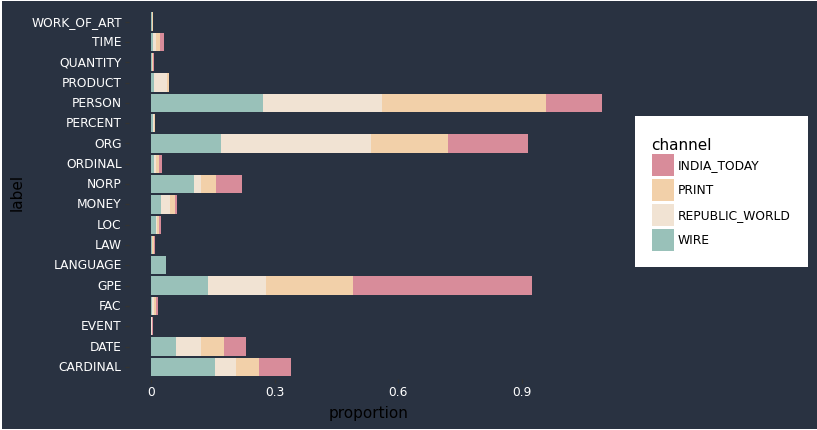

```python
ggplot(label_prop_df,  aes(x="label" , y="proportion" , fill="channel")) \
 + geom_col() \
 + coord_flip() \
 + cat_colors \
 + mt \
 + theme(panel_grid_minor=element_blank() , panel_grid_major=element_blank())
```

As can be seen above, as expected, channels mostly talk about People,Organizations Locations, Dates and Numbers.

Below, let's try to see within each category how each channel fares.

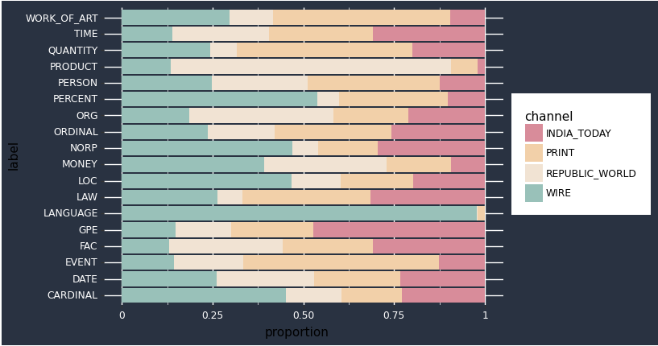

```python
ggplot(label_prop_df,  aes(x="label" , y="proportion" , fill="channel")) \
 + geom_col(position="fill") \
 + coord_flip() \
 + cat_colors \
 + mt
```

### Entity Counts

- Let's try and analyse how often each *entity* is mentioned within a channel and then compare these proportions
- For example let's say Modi is talked about in half of A's videos and only in 10 % percent of B's Videos , similary we can extend the analysis to different categories of labels as well.

```python
entity_count_df = entity_df.groupby(["channel" , "label" ])["text"].value_counts(normalize=True).reset_index(name="counts")
```

- Lets convert counts to proportions

```python
#entity_count_df["counts"] = entity_count_df.groupby("channel").apply(lambda df:df["counts"]/df["counts"].sum()).reset_index(drop=True)
```

```python
entity_count_df
```

|  | channel | label | text | counts |
| --- | --- | --- | --- | --- |
| 0 | INDIA_TODAY | CARDINAL | https://www.indiatoday.in/ | 0.425688 |
| 1 | INDIA_TODAY | CARDINAL | two | 0.030065 |
| 2 | INDIA_TODAY | CARDINAL | 2020 | 0.027515 |
| 3 | INDIA_TODAY | CARDINAL | one | 0.027090 |
| 4 | INDIA_TODAY | CARDINAL | four | 0.023372 |
| ... | ... | ... | ... | ... |
| 20208 | WIRE | WORK_OF_ART | what ails the ias | 0.066667 |
| 20209 | WIRE | WORK_OF_ART | yeh un | 0.066667 |
| 20210 | WIRE | WORK_OF_ART | \| kashmir | 0.066667 |
| 20211 | WIRE | WORK_OF_ART | टेरर | 0.066667 |
| 20212 | WIRE | WORK_OF_ART | सामना | 0.066667 |

20213 rows × 4 columns

```python
from plotnine import *
```

### Defining a custom Theme

- Like in R with ggplot you can define your own custom theme to give more life to the plot
- let's define a theme with dark background and smoother contrasting colors

```python
bgcolor = "#293241"
mt = theme(panel_background=element_rect(fill=bgcolor)
           ,plot_background=element_rect(fill=bgcolor)
           , axis_text_x = element_text(color="white")
           , axis_text_y = element_text(color="white"))

cat_colors = scale_fill_manual(values = ["#d88c9a","#f2d0a9" , "#f1e3d3" , "#99c1b9" , "#8e7dbe"])
```

## Analysing People

```python
person_prop = entity_count_df[(entity_count_df["label"] == "PERSON")]
```

```python
people_talked_on_almost_all = person_prop.groupby("text")["channel"]\
                                         .count()\
                                         .reset_index(name="counts")\
                                         .sort_values("counts" , ascending=False)
```

```python
people_talked_on_almost_all
```

|  | text | counts |
| --- | --- | --- |
| 3894 | pm modi | 4 |
| 203 | aishe ghosh | 4 |
| 3764 | p chidambaram | 4 |
| 1833 | gautam gambhir | 4 |
| 4940 | shiv sena | 4 |
| ... | ... | ... |
| 2280 | itbp | 1 |
| 2279 | it.catch | 1 |
| 2278 | isst | 1 |
| 2277 | ismat ara | 1 |
| 6407 | ₹5.95 lac worth | 1 |

6408 rows × 2 columns

```python
people_talked_on_almost_all = people_talked_on_almost_all[people_talked_on_almost_all["counts"] > 2]
```

```python
people_talked_on_almost_all.shape
```

```
(178, 2)
```

```python
people_talked_on_almost_all["text"].values
```

```
array(['pm modi', 'aishe ghosh', 'p chidambaram', 'gautam gambhir',
       'shiv sena', 'mamata banerjee', 'shaheen bagh', 'mohan bhagwat',
       'rahul gandhi', "rahul gandhi's", 'umar khalid', 'gandhi',
       'jyotiraditya scindia', 'nirmala sitharaman', 'covid',
       'chidambaram', "nirmala sitharaman's", 'mps', 'hemant soren',
       'amit shah', 'cm', 'the shiv sena', 'jharkhand', "narendra modi's",
       'the lok sabha', "amit shah's", 'narendra modi', 'vardhan',
       'mamata', 'arvind kejriwal', 'mlas', 'lok sabha', 'singh',
       'sitharaman', 'donald trump', 'yogi adityanath', 'modi-shah',
       'savarkar', 'modi', 'murli manohar joshi', 'bihar', 'jds', 'bjp',
       'sonia gandhi', 'dilip ghosh', 'mayawati', 'ramesh pokhriyal',
       'taj mahal', 'amarinder singh', 'niti aayog', 'naxal',
       'smriti irani', 'ajit doval', 'riyaz naikoo', 'isis',
       'digvijaya singh', 'deepender hooda', 'deepika padukone',
       "deepika padukone's", 'amit shah\n', 'nitin gadkari', 'reddy',
       'telangana', 'sitaram yechury', 'irrfan khan', 'digvijay singh',
       'नहीं है', 'jairam ramesh', 'sonia', 'ravi shankar prasad',
       'ravi shankar', 'ajit pawar', 'rashtrapati bhavan',
       'melania trump', 'devendra fadnavis', 'rishi kapoor', 'melania',
       'rajya sabha mp', 'ranjan gogoi', 'mehbooba mufti',
       'indira gandhi', 'randeep surjewala', 'imran khan',
       'randeep singh surjewala', 'jama masjid', 'icmr', 'sri sri',
       'rajiv kumar', 'nitish kumar', 'bihar\n', 'vasundhara raje',
       'p. chidambaram', 'kamal nath', 'bjp mps', 'kanhaiya kumar',
       'arif mohammed khan', 'bjp mp', 'pulwama', 'mahatma gandhi',
       'bjp\n', 'bipin rawat', 'priyanka gandhi vadra', 'priyanka gandhi',
       'bhima koregaon', 'amphan', 'bharat mata', 'xi jinping',
       'yashwant sinha', 'asaduddin owaisi', 'yogendra yadav', 'bcci',
       'kisan', "yogi adityanath's", 'prakash javadekar', 'babul supriyo',
       'kumaraswamy', 'baba ramdev', 'ayushman bharat', 'raghav chadha',
       'boris johnson', 'owaisi', 'anurag thakur', "nitish kumar's",
       'rajya sabha', 'jdu', 'nizamuddin markaz', 'rajnath singh',
       'robert vadra', 'rajiv gandhi', 'rajinikanth',
       'manohar lal khattar', 'mann ki baat', 'manmohan singh',
       'anil baijal', 'nsa ajit doval', 'jnusu', 'joe biden',
       'manish sisodia', 'jp nadda', 'oic', 'uddhav thackeray',
       'anti-caa', 'mandis', 'anti-india', 'omar abdullah', 'rahul bajaj',
       'bs yeddyurappa', 'rahul', 'uttar pradesh', 'rks bhadauria',
       'tajinder bagga', 'abhishek manu singhvi', 'sanjeev sanyal',
       'aaditya thackeray', 'sharad pawar', 'mukul rohatgi', 'msmes',
       'garib kalyan', 'hardeep singh puri', 'shivraj singh chouhan',
       'hizbul mujahideen', 'aarogya setu', 'aayog', 'shah',
       'nathuram godse', 'sambit patra', 'godman nithyananda',
       'sanjay singh', 'sanjay nirupam', 'shaktikanta das',
       'abhijit banerjee', 'hafiz saeed', 'sachin', "donald trump's",
       'donald trump\n', 'shaheen bagh\n', 'gurugram', 'farooq abdullah'],
      dtype=object)
```

```python
person_prop = person_prop[person_prop["text"].isin(people_talked_on_almost_all["text"])]
```

```python
person_prop.shape
```

```
(578, 4)
```

```python
person_prop
```

|  | channel | label | text | counts |
| --- | --- | --- | --- | --- |
| 5314 | INDIA_TODAY | PERSON | bjp | 0.065725 |
| 5315 | INDIA_TODAY | PERSON | shaheen bagh | 0.040811 |
| 5317 | INDIA_TODAY | PERSON | amit shah | 0.019005 |
| 5318 | INDIA_TODAY | PERSON | narendra modi | 0.018456 |
| 5319 | INDIA_TODAY | PERSON | donald trump | 0.016751 |
| ... | ... | ... | ... | ... |
| 19739 | WIRE | PERSON | vardhan | 0.000381 |
| 19748 | WIRE | PERSON | xi jinping | 0.000381 |
| 19751 | WIRE | PERSON | yashwant sinha | 0.000381 |
| 19755 | WIRE | PERSON | yogendra yadav | 0.000381 |
| 19756 | WIRE | PERSON | yogi adityanath's | 0.000381 |

578 rows × 4 columns

```python
import warnings
warnings.filterwarnings('ignore')
```

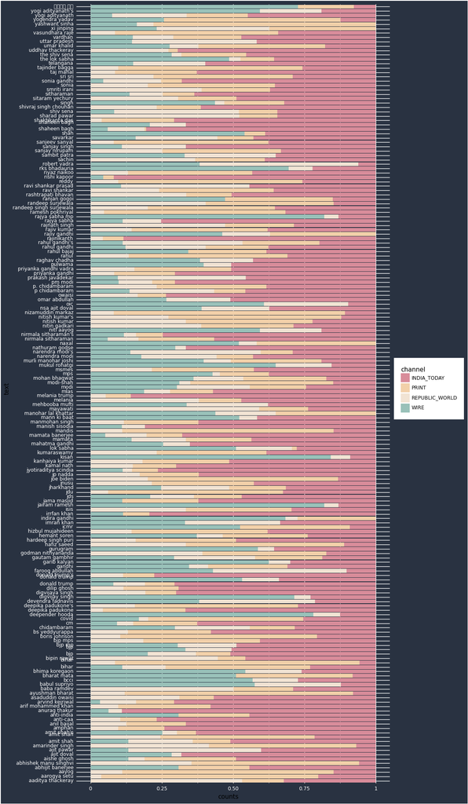

```python
ggplot(person_prop , aes(x="text" , y="counts" , fill="channel")) \
+ geom_col(position="fill")\
+ coord_flip() \
+ cat_colors \
+ mt\
+ theme(figure_size=(10,25))
```

```python
def plotChannelText(df ,figure_size=(2,2)):
  p = ggplot(df , aes(x="text" , y="counts" , fill="channel")) \
  + geom_col(position="fill")\
  + coord_flip() \
  + cat_colors \
  + mt\
  + theme(figure_size=figure_size)
  print(p)
```

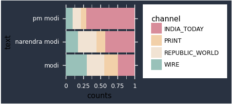

```python
plot_person = person_prop[person_prop.text.isin(["pm modi" , "narendra modi" , "modi"])]
plotChannelText(plot_person)
```

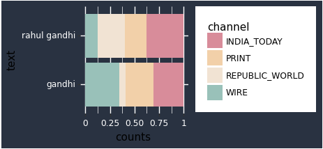

```python
plot_person = person_prop[person_prop.text.isin(["gandhi" , "rahul gandhi" ])]
plotChannelText(plot_person)
```

## Location Analysis

```python
def popularInLabel(label):
  person_prop = entity_count_df[(entity_count_df["label"] == label)]
  people_talked_on_almost_all = person_prop.groupby("text")["channel"]\
                                         .count()\
                                         .reset_index(name="counts")\
                                         .sort_values("counts" , ascending=False)
  people_talked_on_almost_all = people_talked_on_almost_all[people_talked_on_almost_all["counts"] > 2]
  person_prop = person_prop[person_prop["text"].isin(people_talked_on_almost_all["text"])]
  return person_prop
```

```python
plot_df = popularInLabel("GPE")
plot_df.head()
```

|  | channel | label | text | counts |
| --- | --- | --- | --- | --- |
| 1885 | INDIA_TODAY | GPE | india | 0.311672 |
| 1886 | INDIA_TODAY | GPE | bollywood | 0.047732 |
| 1887 | INDIA_TODAY | GPE | delhi | 0.023684 |
| 1888 | INDIA_TODAY | GPE | maharashtra | 0.003083 |
| 1889 | INDIA_TODAY | GPE | mumbai | 0.002629 |

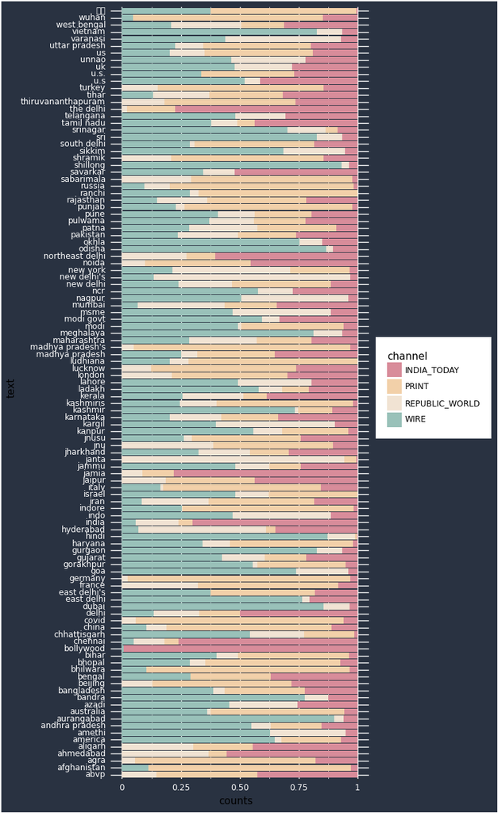

```python
plotChannelText(plot_df, (5,15))
```

### Kashmir

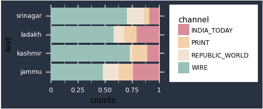

```python
sub_plot_df = plot_df[plot_df["text"].isin(["kashmir" , "srinagar" , "jammu" , "ladakh"])]
plotChannelText(sub_plot_df , (3,2))
```

### International

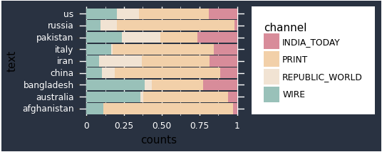

```python
sub_plot_df = plot_df[plot_df["text"].isin(["afghanistan" ,"bangladesh" ,"srilanka" , "pakistan","us" , "iran" , "italy" , "china" ,"australia" , "russia"])]
plotChannelText(sub_plot_df , (3,2))
```

### Metros

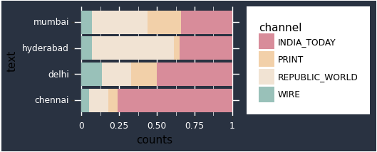

```python
sub_plot_df = plot_df[plot_df["text"].isin(["delhi" , "mumbai" , "chennai" , "kolkata" , "hyderabad" ,"bangalore"])]
plotChannelText(sub_plot_df , (3,2))
```

### States

```python
indian_states_list = [t.lower() for t in open("indian_states_list.txt").read().split("\n")]
```

```python
indian_states_list[:5]
```

```
['andhra pradesh', 'arunachal pradesh', 'assam', 'bihar', 'chhattisgarh']
```

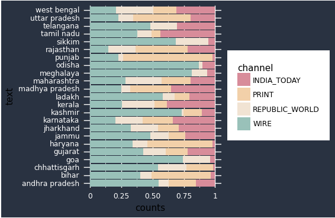

```python
sub_plot_df = plot_df[plot_df["text"].isin(indian_states_list)]
plotChannelText(sub_plot_df , (3,4))
```

### Cities

```python
geo_list = [t.lower() for t in open("indian_cities_list.txt").read().split("\n")]
```

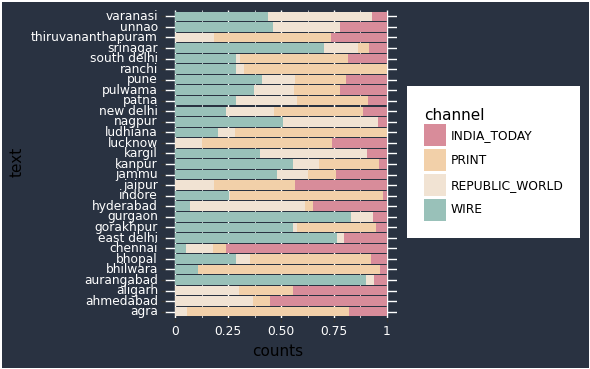

```python
sub_plot_df = plot_df[plot_df["text"].isin(geo_list)]
plotChannelText(sub_plot_df , (3,4))
```

## Organization

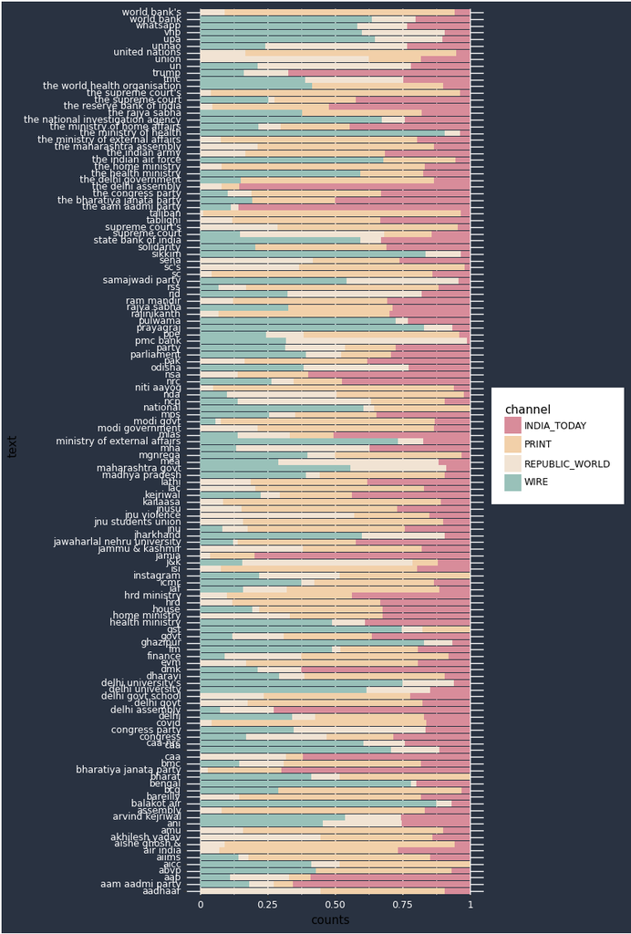

```python
plot_df = popularInLabel("ORG")
plotChannelText(plot_df , (5,15))
```

### Political Parties

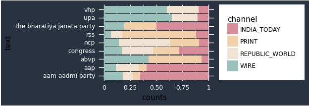

```python
sub_plot_df = plot_df[plot_df["text"].isin(["aam aadmi party" ,"vhp","upa", "aap" , "ncp","congress","bjp" , "the bharatiya janata party" , "rss" , "abvp"])]
plotChannelText(sub_plot_df , (3,2))
```

### Government

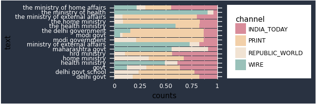

```python
sub_plot_df = plot_df[plot_df["text"].str.match(".*(ministry|gov).*")]
plotChannelText(sub_plot_df , (3,2))
```